# Superstore Sales Analysis

Shoaib Akhtar

# Executive Summary

This report presents a comprehensive analysis of **9,994 sales transactions** from the Sample Superstore dataset covering **2014–2017**. The analysis examines sales, profitability, customer segments, regions, products, and monthly trends.

## Key Findings

| Category | Sales…. | Profit…. | Margin |
| --- | --- | --- | --- |
| Technology | 836154 | 145455 | 17.4% |
| Office Supplies | 719047 | 122491 | 17.0% |
| Furniture | 742000 | 18451 | 2.5% |

# 1. Setup

```r
library(tidyverse)
library(lubridate)
library(scales)
library(knitr)

knitr::opts_chunk$set(
  echo = TRUE,
  warning = FALSE,
  message = FALSE,
  fig.width = 8,
  fig.height = 5
)
```

# 2. Load and Inspect Data

```r
setwd("E:/R_Section/Superstore-Sales-Analysis-R/data")
superstore <- read.csv("Sample-Superstore.csv")

dim(superstore)
```

```
## [1] 9994   21
```

```r
glimpse(superstore)
```

```
## Rows: 9,994
## Columns: 21
## $ Row.ID        <int> 1, 2, 3, 4, 5, 6, 7, 8, 9, 10, 11, 12, 13, 14, 15, 16, 1…
## $ Order.ID      <chr> "CA-2016-152156", "CA-2016-152156", "CA-2016-138688", "U…
## $ Order.Date    <chr> "11/8/2016", "11/8/2016", "6/12/2016", "10/11/2015", "10…
## $ Ship.Date     <chr> "11/11/2016", "11/11/2016", "6/16/2016", "10/18/2015", "…
## $ Ship.Mode     <chr> "Second Class", "Second Class", "Second Class", "Standar…
## $ Customer.ID   <chr> "CG-12520", "CG-12520", "DV-13045", "SO-20335", "SO-2033…
## $ Customer.Name <chr> "Claire Gute", "Claire Gute", "Darrin Van Huff", "Sean O…
## $ Segment       <chr> "Consumer", "Consumer", "Corporate", "Consumer", "Consum…
## $ Country       <chr> "United States", "United States", "United States", "Unit…
## $ City          <chr> "Henderson", "Henderson", "Los Angeles", "Fort Lauderdal…
## $ State         <chr> "Kentucky", "Kentucky", "California", "Florida", "Florid…
## $ Postal.Code   <int> 42420, 42420, 90036, 33311, 33311, 90032, 90032, 90032, …
## $ Region        <chr> "South", "South", "West", "South", "South", "West", "Wes…
## $ Product.ID    <chr> "FUR-BO-10001798", "FUR-CH-10000454", "OFF-LA-10000240",…
## $ Category      <chr> "Furniture", "Furniture", "Office Supplies", "Furniture"…
## $ Sub.Category  <chr> "Bookcases", "Chairs", "Labels", "Tables", "Storage", "F…
## $ Product.Name  <chr> "Bush Somerset Collection Bookcase", "Hon Deluxe Fabric …
## $ Sales         <dbl> 261.9600, 731.9400, 14.6200, 957.5775, 22.3680, 48.8600,…
## $ Quantity      <int> 2, 3, 2, 5, 2, 7, 4, 6, 3, 5, 9, 4, 3, 3, 5, 3, 6, 2, 2,…
## $ Discount      <dbl> 0.00, 0.00, 0.00, 0.45, 0.20, 0.00, 0.00, 0.20, 0.20, 0.…
## $ Profit        <dbl> 41.9136, 219.5820, 6.8714, -383.0310, 2.5164, 14.1694, 1…
```

The dataset contains **9,994 observations and 21 variables**.

```r
# Missing values
colSums(is.na(superstore))
```

```
##        Row.ID      Order.ID    Order.Date     Ship.Date     Ship.Mode
##             0             0             0             0             0
##   Customer.ID Customer.Name       Segment       Country          City
##             0             0             0             0             0
##         State   Postal.Code        Region    Product.ID      Category
##             0             0             0             0             0
##  Sub.Category  Product.Name         Sales      Quantity      Discount
##             0             0             0             0             0
##        Profit
##             0
```

```r
# Duplicate records
sum(duplicated(superstore))
```

```
## [1] 0
```

The original analysis found no missing values and no duplicate records.

# 3. Data Preparation

The Order Date and Ship Date variables were converted to Date format to enable time-based analysis.

```r
superstore$Ship.Date<- mdy(superstore$Ship.Date)
superstore$Order.Date<- mdy(superstore$Order.Date)
str(superstore[c("Order.Date", "Ship.Date")])
```

```
## 'data.frame':    9994 obs. of  2 variables:
##  $ Order.Date: Date, format: "2016-11-08" "2016-11-08" ...
##  $ Ship.Date : Date, format: "2016-11-11" "2016-11-11" ...
```

# 4. Exploratory Data Analysis

## 4.1 Sales Distribution

```r
superstore %>%
  summarise(
    Mean = mean(Sales, na.rm = TRUE),
    Median = median(Sales, na.rm = TRUE),
    SD = sd(Sales, na.rm = TRUE),
    Minimum = min(Sales, na.rm = TRUE),
    Maximum = max(Sales, na.rm = TRUE)
  ) %>%
  kable(digits = 2)
```

| Mean | Median | SD | Minimum | Maximum |
| --- | --- | --- | --- | --- |
| 229.86 | 54.49 | 623.25 | 0.44 | 22638.48 |

The original report found a mean sale of **$229.86**, median of **$54.49**, standard deviation of **$623.25**, minimum of **$0.44**, and maximum of **$22,638.48**. The distribution is positively skewed because a relatively small number of high-value orders increase the mean.

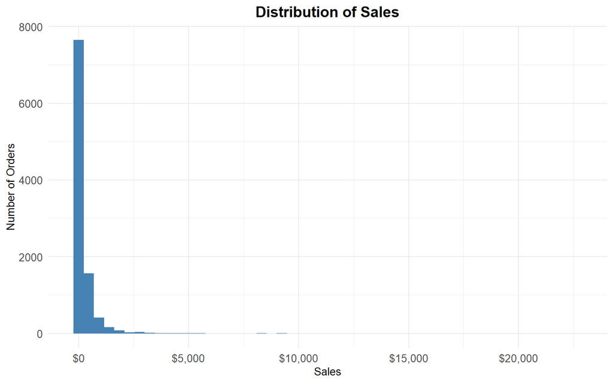

```r
ggplot(superstore, aes(x = Sales), fill = colour) +
  geom_histogram(bins = 50, fill = "steelblue") +
  scale_x_continuous(labels = dollar) +
  labs(title = "Distribution of Sales",
       x = "Sales", y = "Number of Orders") +
  theme_minimal()+
  theme(plot.title = element_text(hjust = 0.5, size = 14,
  face = "bold"), axis.title = element_text(size = 10),
  axis.text = element_text(size = 10))
```

**Business insight:** Both frequent small purchases and occasional large orders are important revenue sources.

## 4.2 Sales Outlier Analysis

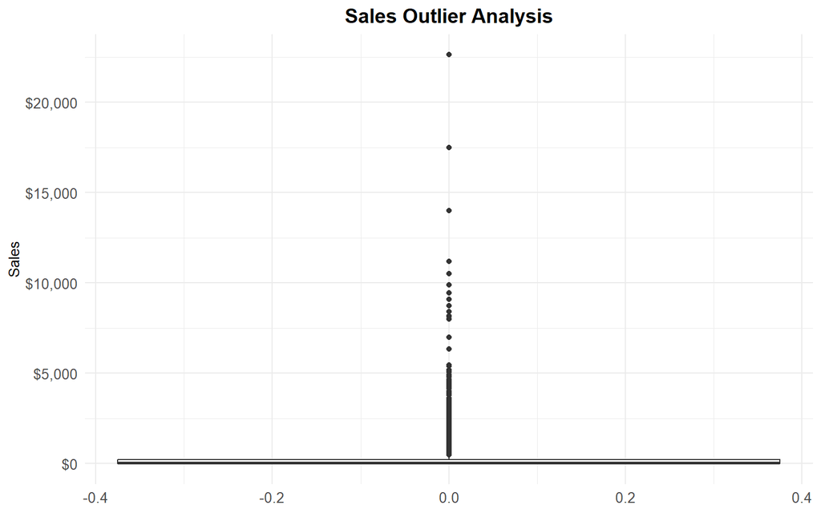

```r
ggplot(superstore, aes(y = Sales), fill = colour ) +
  geom_boxplot() +
  scale_y_continuous(labels = dollar) +
  labs(title = "Sales Outlier Analysis", y = "Sales") +
  theme_minimal() +
  theme(plot.title = element_text(hjust = 0.5, size = 14,
  face = "bold"), axis.title = element_text(size = 10),
  axis.text = element_text(size = 10))
```

The maximum sale was **$22,638.48**, indicating an extreme high-value observation.

**Business insight:** High-value orders should be monitored separately because they may represent key customers or bulk purchases.

## 4.3 Sales by Category

```r
category_sales <- superstore %>%
  group_by(Category) %>%
  summarise(Total_Sales = sum(Sales, na.rm = TRUE)) %>%
  arrange(desc(Total_Sales))

category_sales %>% kable(digits = 0)
```

| Category | Total_Sales |
| --- | --- |
| Technology | 836154 |
| Furniture | 742000 |
| Office Supplies | 719047 |

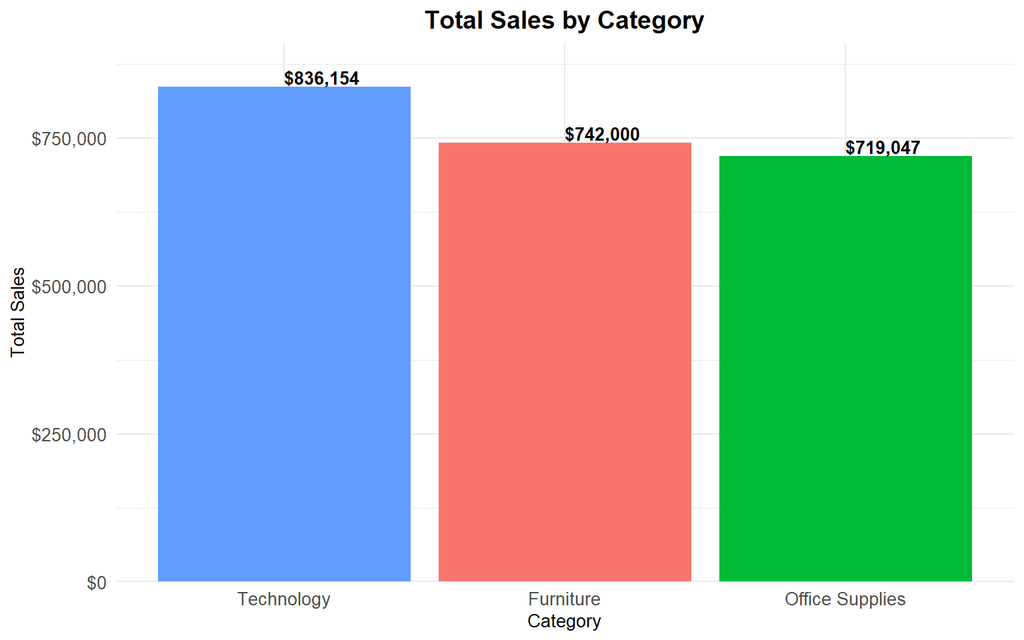

```r
ggplot(category_sales,
       aes(x = reorder(Category, -Total_Sales), y = Total_Sales, fill = Category)) +
  geom_col() +
  geom_text(aes(label = dollar(round(Total_Sales))), vjust = -0.2,  hjust = 0, size = 3.5, fontface="bold") +
  scale_y_continuous(labels = dollar, expand = expansion(mult = c(0, 0.09))) +
  labs(title = "Total Sales by Category",
       x = "Category", y = "Total Sales") +
  theme_minimal() +
  theme(plot.title = element_text(hjust = 0.5, size = 14,
  face = "bold"), axis.title = element_text(size = 10),
  axis.text = element_text(size = 10)) +
  theme(legend.position = "none")
```

Technology is the strongest revenue category at approximately **$836,154**.

## 4.4 Profit by Category

```r
category_profit <- superstore %>%
  group_by(Category) %>%
  summarise(
    Total_Sales = sum(Sales, na.rm = TRUE),
    Total_Profit = sum(Profit, na.rm = TRUE)
  ) %>%
  mutate(Margin = Total_Profit / Total_Sales * 100) %>%
  arrange(desc(Total_Profit))

category_profit %>% kable(digits = 2)
```

| Category | Total_Sales | Total_Profit | Margin |
| --- | --- | --- | --- |
| Technology | 836154.0 | 145454.95 | 17.40 |
| Office Supplies | 719047.0 | 122490.80 | 17.04 |
| Furniture | 741999.8 | 18451.27 | 2.49 |

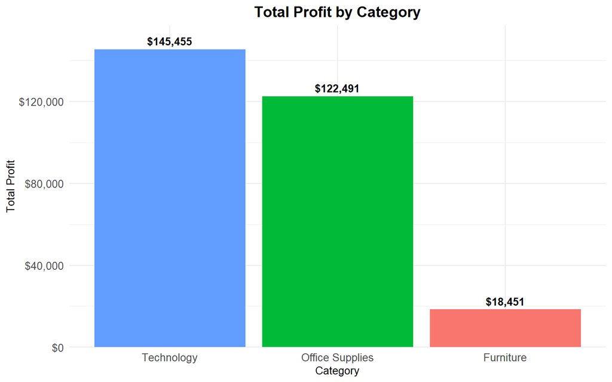

```r
ggplot(category_profit, aes(x = reorder(Category, -Total_Profit),
     y = Total_Profit, fill = Category)) +
    geom_col() +
    geom_text(aes(label = dollar(round(Total_Profit))),
    vjust = -0.5, hjust = 0.5, size =3.5, fontface="bold") +
    scale_y_continuous(labels = dollar, expand = expansion(mult = c(0, 0.08)))+
    labs( title = "Total Profit by Category", x = "Category",
    y = "Total Profit") +
    theme_minimal()+theme(plot.title = element_text(hjust = 0.5, size = 14,
    face = "bold"), axis.title =
    element_text(size = 10), axis.text = element_text(size = 10)) +
    theme(legend.position = "none")
```

Furniture generates only about a **2.5% margin**, despite substantial sales.

**Business insight:** Review Furniture pricing, costs, and discount strategies.

## 4.5 Sales by Region

```r
region_sales <- superstore %>%
  group_by(Region) %>%
  summarise(Total_Sales = sum(Sales, na.rm = TRUE)) %>%
  arrange(desc(Total_Sales))

region_sales %>% kable(digits = 0)
```

| Region | Total_Sales |
| --- | --- |
| West | 725458 |
| East | 678781 |
| Central | 501240 |
| South | 391722 |

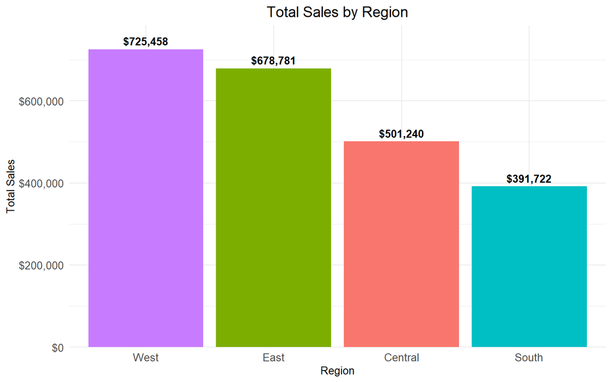

```r
ggplot(region_sales, aes(x = reorder(Region, -Total_Sales),
    y = Total_Sales, fill = Region)) + geom_col() +
    geom_text(aes(label = dollar(round(Total_Sales))), vjust= -0.5, hjust=0.5,
    size=3.5, fontface= "bold") +
    scale_y_continuous(labels = dollar, expand =
    expansion(mult = c(0, 0.08))) +
    labs( title = "Total Sales by Region",  x = "Region", y = "Total Sales") +
    theme_minimal() +
    theme( plot.title = element_text(hjust = 0.5,size = 14,
    fontface="bold"), axis.title = element_text(size = 10), axis.text =
    element_text(size = 10),legend.position = "none")
```

West leads with approximately **$725,458** in sales, while South records approximately **$391,722**.

## 4.6 Profit by Region

```r
region_profit <- superstore %>%
  group_by(Region) %>%
  summarise(Total_Profit = sum(Profit, na.rm = TRUE)) %>%
  arrange(desc(Total_Profit))

region_profit %>% kable(digits = 0)
```

| Region | Total_Profit |
| --- | --- |
| West | 108418 |
| East | 91523 |
| South | 46749 |
| Central | 39706 |

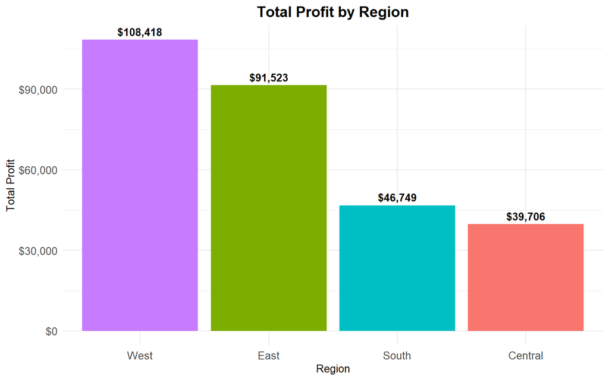

```r
ggplot(region_profit, aes(x = reorder(Region,-Total_Profit),
       y = Total_Profit, fill = Region)) + geom_col() +
    geom_text(aes(label= dollar(round(Total_Profit))), vjust= -0.5, hjust=0.5,
       size = 3.5, fontface="bold") +
    scale_y_continuous(labels = dollar) +
    labs( title = "Total Profit by Region",   x = "Region", y = "Total Profit")+
       theme_minimal() +
    theme( plot.title = element_text(size = 14,hjust=0.5,
       face="bold"), axis.title = element_text(size=10),
       axis.text= element_text(size = 10), legend.position = "none")
```

West and East are the strongest profit centers.

## 4.7 Monthly Sales Trend

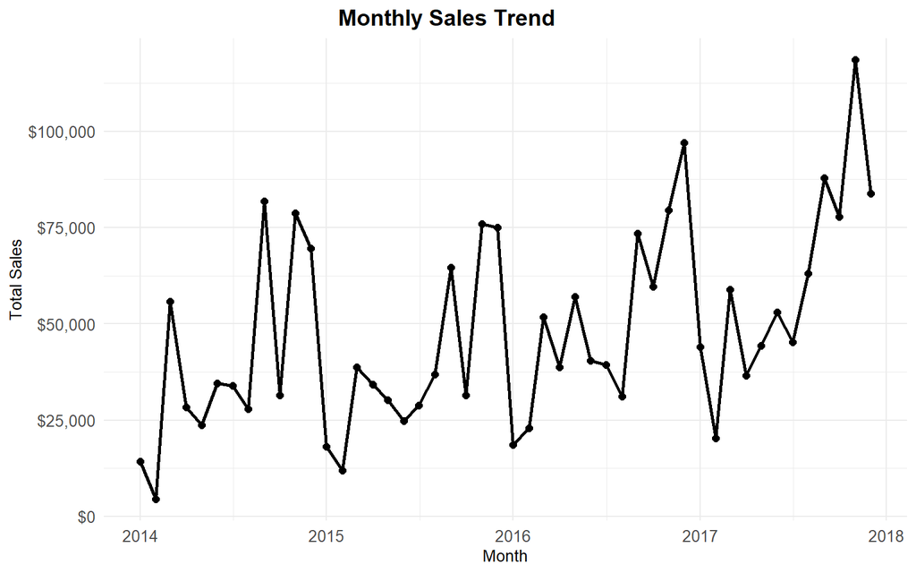

```r
monthly_sales <- superstore %>%
  group_by(Month = floor_date(`Order.Date`, "month")) %>%
  summarise(Total_Sales = sum(Sales, na.rm = TRUE))

ggplot(monthly_sales, aes(x = Month, Total_Sales)) +
    geom_line(linewidth = 1) + geom_point(size = 2) +
    scale_y_continuous(labels = dollar) +
    labs( title = "Monthly Sales Trend", x = "Month",y = "Total Sales") +
    theme_minimal() +
    theme( plot.title = element_text(size = 14, hjust=0.4,
      face="bold"), axis.title = element_text(size=10),
    axis.text= element_text(size = 10), legend.position = "none")
```

Sales show an overall upward trend from 2014 to 2017, with the strongest months occurring toward the end of 2017.

## 4.8 Monthly Profit Trend

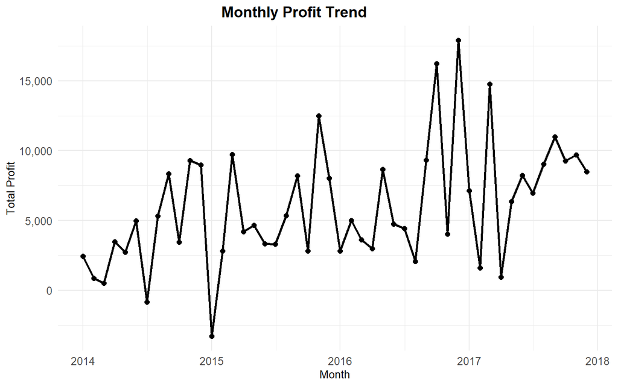

```r
monthly_profit <- superstore %>%
  group_by(Month = floor_date(`Order.Date`, "month")) %>%
  summarise(Total_Profit = sum(Profit, na.rm = TRUE))

 ggplot(monthly_profit, aes(x= Month, y= Total_Profit)) +
    geom_line(linewidth= 1) + geom_point(size=2)+ scale_y_continuous(labels =
    comma)+ labs(title = "Monthly Profit Trend", x= "Month", y = "Total Profit")+
    theme_minimal() + theme(plot.title = element_text(size = 14, hjust=0.4,
    face="bold"), axis.title = element_text(size=10),
    axis.text= element_text(size = 10), legend.position = "none")
```

Profitability improves over time but remains volatile, including negative-profit months.

## 4.9 Sales by Customer Segment

```r
segment_sales <- superstore %>%
  group_by(Segment) %>%
  summarise(Total_Sales = sum(Sales, na.rm = TRUE)) %>%
  mutate(Percent = Total_Sales / sum(Total_Sales) * 100) %>%
  arrange(desc(Total_Sales))

segment_sales %>% kable(digits = 2)
```

| Segment | Total_Sales | Percent |
| --- | --- | --- |
| Consumer | 1161401.3 | 50.56 |
| Corporate | 706146.4 | 30.74 |
| Home Office | 429653.2 | 18.70 |

## 4.10 Profit by Customer Segment

```r
segment_profit <- superstore %>%
  group_by(Segment) %>%
  summarise(Total_Profit = sum(Profit, na.rm = TRUE)) %>%
  arrange(desc(Total_Profit))

segment_profit %>% kable(digits = 0)
```

| Segment | Total_Profit |
| --- | --- |
| Consumer | 134119 |
| Corporate | 91979 |
| Home Office | 60299 |

Consumer is both the largest revenue source and the most profitable segment.

## 4.11 Sales by Sub-Category

```r
subcategory_sales <- superstore %>%
  group_by(`Sub.Category`) %>%
  summarise(Total_Sales = sum(Sales, na.rm = TRUE)) %>%
  arrange(desc(Total_Sales))

subcategory_sales %>% kable(digits = 0)
```

| Sub.Category | Total_Sales |
| --- | --- |
| Phones | 330007 |
| Chairs | 328449 |
| Storage | 223844 |
| Tables | 206966 |
| Binders | 203413 |
| Machines | 189239 |
| Accessories | 167380 |
| Copiers | 149528 |
| Bookcases | 114880 |
| Appliances | 107532 |
| Furnishings | 91705 |
| Paper | 78479 |
| Supplies | 46674 |
| Art | 27119 |
| Envelopes | 16476 |
| Labels | 12486 |
| Fasteners | 3024 |

Top performers in the original report include **Phones ($330,007)** and **Chairs ($328,449)**.

## 4.12 Profit by Sub-Category

```r
subcategory_profit <- superstore %>%
  group_by(`Sub.Category`) %>%
  summarise(Total_Profit = sum(Profit, na.rm = TRUE)) %>%
  arrange(desc(Total_Profit))

subcategory_profit %>% kable(digits = 0)
```

| Sub.Category | Total_Profit |
| --- | --- |
| Copiers | 55618 |
| Phones | 44516 |
| Accessories | 41937 |
| Paper | 34054 |
| Binders | 30222 |
| Chairs | 26590 |
| Storage | 21279 |
| Appliances | 18138 |
| Furnishings | 13059 |
| Envelopes | 6964 |
| Art | 6528 |
| Labels | 5546 |
| Machines | 3385 |
| Fasteners | 950 |
| Supplies | -1189 |
| Bookcases | -3473 |
| Tables | -17725 |

The original report identifies **Copiers ($55,618)** as the top sub-category by profit and **Tables (-$17,725)** as the largest loss-maker.

## 4.13 Top 10 Products by Sales

```r
top10_sales <- superstore %>%
  group_by(`Product.Name`) %>%
  summarise(Total_Sales = sum(Sales, na.rm = TRUE)) %>%
  arrange(desc(Total_Sales)) %>%
  slice_head(n = 10)

top10_sales %>% kable(digits = 0)
```

| Product.Name | Total_Sales |
| --- | --- |
| Canon imageCLASS 2200 Advanced Copier | 61600 |
| Fellowes PB500 Electric Punch Plastic Comb Binding Machine with Manual Bind | 27453 |
| Cisco TelePresence System EX90 Videoconferencing Unit | 22638 |
| HON 5400 Series Task Chairs for Big and Tall | 21871 |
| GBC DocuBind TL300 Electric Binding System | 19823 |
| GBC Ibimaster 500 Manual ProClick Binding System | 19024 |
| Hewlett Packard LaserJet 3310 Copier | 18840 |
| HP Designjet T520 Inkjet Large Format Printer - 24” Color | 18375 |
| GBC DocuBind P400 Electric Binding System | 17965 |
| High Speed Automatic Electric Letter Opener | 17030 |

The Canon imageCLASS 2200 Advanced Copier is the leading product by sales in the original analysis.

## 4.14 Top 10 Products by Profit

```r
top10_profit <- superstore %>%
  group_by(`Product.Name`) %>%
  summarise(Total_Profit = sum(Profit, na.rm = TRUE)) %>%
  arrange(desc(Total_Profit)) %>%
  slice_head(n = 10)

top10_profit %>% kable(digits = 0)
```

| Product.Name | Total_Profit |
| --- | --- |
| Canon imageCLASS 2200 Advanced Copier | 25200 |
| Fellowes PB500 Electric Punch Plastic Comb Binding Machine with Manual Bind | 7753 |
| Hewlett Packard LaserJet 3310 Copier | 6984 |
| Canon PC1060 Personal Laser Copier | 4571 |
| HP Designjet T520 Inkjet Large Format Printer - 24” Color | 4095 |
| Ativa V4110MDD Micro-Cut Shredder | 3773 |
| 3D Systems Cube Printer, 2nd Generation, Magenta | 3718 |
| Plantronics Savi W720 Multi-Device Wireless Headset System | 3696 |
| Ibico EPK-21 Electric Binding System | 3345 |
| Zebra ZM400 Thermal Label Printer | 3344 |

The Canon imageCLASS 2200 Advanced Copier is also the leading product by profit.

# 5. Key Findings

### Weaknesses

- Furniture: only 2.5% profit margin.
- Tables: approximately $17,725 loss.
- South: lowest regional sales.
- Bookcases and Supplies: also loss-making.

### Opportunities

- Expand Technology product lines.
- Target marketing toward South.
- Develop Consumer loyalty programs.
- Optimize pricing for Tables and Furniture.

# 6. Business Recommendations

1. **Furniture:** investigate costs, discounts, pricing, and supplier terms.
2. **Tables:** review pricing and supplier costs; consider bundling with higher-margin products.
3. **South Region:** increase targeted marketing and investigate customer demand and product availability.
4. **Consumer Segment:** develop loyalty programs, targeted email marketing, and personalized recommendations.

# 7. Conclusion

The analysis demonstrates that revenue and profitability are not the same. Furniture has high sales but very low profitability, while Technology is strong in both sales and profit. Regional differences are substantial, with West leading and South requiring attention. A relatively small number of products also contribute substantially to overall performance.

# 8. Appendix

All tables and visualizations in this report are generated directly from R code, making the analysis reproducible and easier to update when the dataset changes.